# Part II - Ford GoBike System Data Analysis

## by Abdulafeez Adefabi

## Investigation Overview

I looked at how the duration of trips changes with respect to customer type, gender and day of the week. Establishing if there were patterns of trip duration on the different days by user_type or gender.

## Dataset Overview

This data set includes information about individual rides made in a bike-sharing system covering the greater San Francisco Bay area. There are 183412 fordgobike trips in the dataset with 16 fields with some missing values.  
I dropped all missing values from the dataset. Dataset used for this analysis had 174952 observations. I also extracted new fields from existing fields to enrich the analysis.

## (Trips by Day of the Week)

> Thursday had the highest number of trips while saturday had the least trip started.

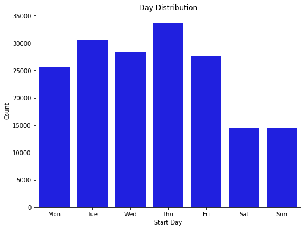

## (Trips by User_type)

> 91% of the rides had a subscriber account with FordBike. The customers accounted for about 9% of the trips.

```
Subscriber    0.905311
Customer      0.094689
Name: user_type, dtype: float64
```

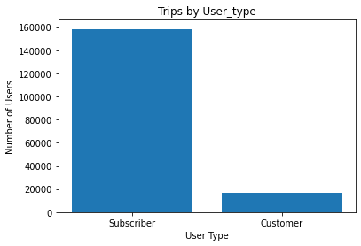

## (Trips By Gender)

The male gender are the major users of fordgobike, accounting for 75% of users. The female gender had about 23%, and the other gender classification had 2% representation.

```
Male      0.745919
Female    0.233235
Other     0.020846
Name: member_gender, dtype: float64
```

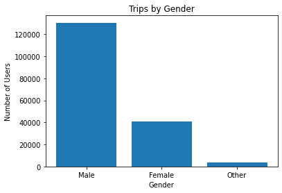

## Duration by Days of the week

We deduce that rides take a longer time on weekends than weekdays. One reason for this could be that riders on weekdays used fordbike to commute to work while on weekends, it's more for exercise and leisure.

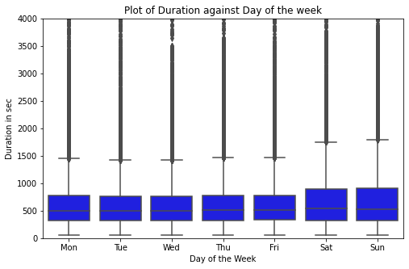

## Duration by Gender Type

The duration across gender show different distribution. Both the female and other gender cover longer distance than the male gender.

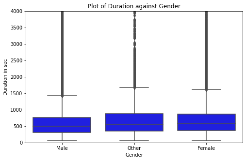

## Duration by User Type

The customer user_type took longer trips than the subscriber riders. This is could be due to customers probably needed the bikes for a one-off journey that was longer unlike a subscriber who already had a mapped out route.

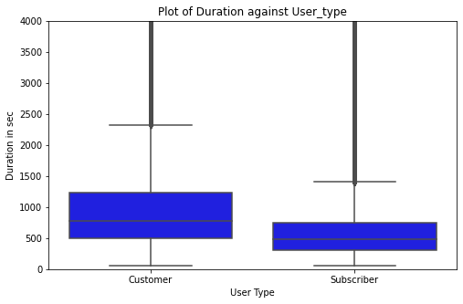

## Trip Duration across Days and Customer Types

Customers went on longer trips than the subscribers, visualization show that those trips were not specific to any day. For every day of the week, customers went on longer trips that the subscribers. On average, a customer would spend about 1200 seconds on a trip as compared to 700 seconds from the subscribers. Although, on weekends, trips are longer for both user types.

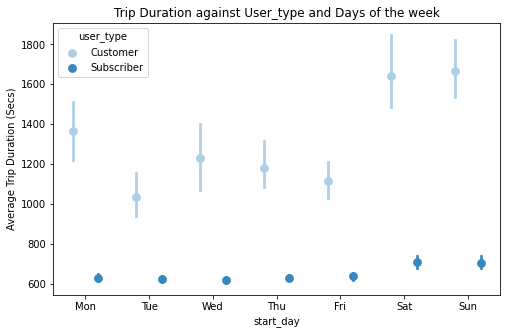

## Trip Duration across Days and Gender

The gender type classified as others have the longest trip duration on all days. We can still see that the female gender took longer than the males on every day of the week in the month of february.

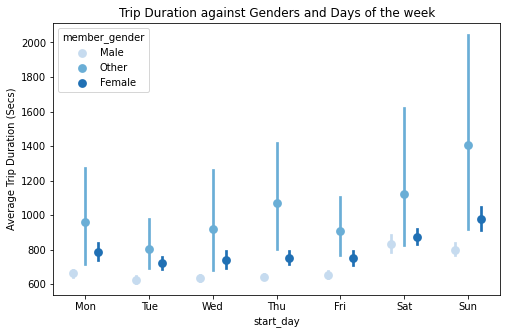